# Peer_greded_ML

Robson Cruz

18/05/2021

## Metodology

In this project we made use of the Human Activity Recognition dataset [3] and select the following variables: classe, accel_belt_x, accel_belt_y, accel_belt_z, accel_forearm_x, accel_forearm_y, accel_forearm_z, accel_arm_x, accel_arm_y, accel_arm_z, accel_dumbbell_x, accel_dumbbell_y and accel_dumbbell_z, which are collected in six subjects. We use the R program language [4] to run the statistics analyze. The original dataset was divided in two other data sets, one for validation and the other to training. We use the Random Forest algorithm to prediction because it is usually one of the two top performing algorithms along with boosting in prediction contests.

## Load packages and Set the work directory

## Processing Data Set and Results

```r
## Elimination of Variables
espl <- with(training, split(num_window, f = classe))
for ( i in 1:4 ) {
  for ( j in (i+1):5) {
    set1 <- paste0("(window numbers for activity ", LETTERS[i],")")
    set2 <- paste0("(window numbers for activity ", LETTERS[j],")")
    result <- ifelse(length(intersect(espl[[i]], espl[[j]])) == 0, "empty", "nonempty")
    cat(paste0(set1, " intersect ", set2, " is ", result,"\n"))
  }
}
```

```
## (window numbers for activity A) intersect (window numbers for activity B) is empty
## (window numbers for activity A) intersect (window numbers for activity C) is empty
## (window numbers for activity A) intersect (window numbers for activity D) is empty
## (window numbers for activity A) intersect (window numbers for activity E) is empty
## (window numbers for activity B) intersect (window numbers for activity C) is empty
## (window numbers for activity B) intersect (window numbers for activity D) is empty
## (window numbers for activity B) intersect (window numbers for activity E) is empty
## (window numbers for activity C) intersect (window numbers for activity D) is empty
## (window numbers for activity C) intersect (window numbers for activity E) is empty
## (window numbers for activity D) intersect (window numbers for activity E) is empty
```

```r
results_test <- sapply(testing, FUN = function(x) !all(is.na(x)))
goodNames <- names(results_test[results_test])
keepNames <- goodNames[-c(1, 3, 4, 5, 6, 7, 60)]
training2 <- training[, keepNames]

## Convert user_name and classe variables to factors
training2$user_name <- factor(training2$user_name)
training2$classe <- factor(training$classe)

## Split the data set into a 60% training and 40% probing data set
set.seed(32031)
inTrain <- createDataPartition(
        y = training2$classe, p = 0.6, list = FALSE
)

trainingSample <- training2[inTrain, ]

## Set the validation data set
test <- training2[-inTrain, ]

## Subset the 'training' data set
test <- test %>% select(
        user_name, classe,
        accel_belt_x, accel_belt_y, accel_belt_z,
        accel_forearm_x, accel_forearm_y, accel_forearm_z,
        accel_arm_x, accel_arm_y, accel_arm_z,
        accel_dumbbell_x, accel_dumbbell_y, accel_dumbbell_z
)
test$classe <- factor(test$classe)
test$user_name <- factor(test$user_name)

trainingSample <- trainingSample %>% select(
        user_name, classe,
        accel_belt_x, accel_belt_y, accel_belt_z,
        accel_forearm_x, accel_forearm_y, accel_forearm_z,
        accel_arm_x, accel_arm_y, accel_arm_z,
        accel_dumbbell_x, accel_dumbbell_y, accel_dumbbell_z
)

## Convert user_name and classe variables to factors
trainingSample$classe <- factor(trainingSample$classe)
```

The summary statistics for training data set and test dataset are shown below.

```r
## Summary statistics
summary(trainingSample)
```

```
##     user_name    classe    accel_belt_x      accel_belt_y     accel_belt_z
##  adelmo  :2336   A:3348   Min.   :-83.000   Min.   :-69.00   Min.   :-275.00
##  carlitos:1867   B:2279   1st Qu.:-21.000   1st Qu.:  3.00   1st Qu.:-162.00
##  charles :2109   C:2054   Median :-15.000   Median : 37.00   Median :-153.00
##  eurico  :1795   D:1930   Mean   : -5.774   Mean   : 30.45   Mean   : -73.31
##  jeremy  :2044   E:2165   3rd Qu.: -5.000   3rd Qu.: 61.00   3rd Qu.:  27.00
##  pedro   :1625            Max.   : 83.000   Max.   :149.00   Max.   : 105.00
##  accel_forearm_x   accel_forearm_y  accel_forearm_z    accel_arm_x
##  Min.   :-498.00   Min.   :-632.0   Min.   :-410.00   Min.   :-383.00
##  1st Qu.:-179.00   1st Qu.:  59.0   1st Qu.:-182.00   1st Qu.:-242.00
##  Median : -56.00   Median : 201.0   Median : -43.00   Median : -37.00
##  Mean   : -61.53   Mean   : 164.2   Mean   : -56.87   Mean   : -58.16
##  3rd Qu.:  76.00   3rd Qu.: 314.0   3rd Qu.:  25.00   3rd Qu.:  85.00
##  Max.   : 477.00   Max.   : 590.0   Max.   : 291.00   Max.   : 437.00
##   accel_arm_y      accel_arm_z      accel_dumbbell_x  accel_dumbbell_y
##  Min.   :-318.0   Min.   :-630.00   Min.   :-237.00   Min.   :-182.00
##  1st Qu.: -54.0   1st Qu.:-143.00   1st Qu.: -50.00   1st Qu.:  -9.00
##  Median :  12.0   Median : -47.00   Median :  -8.00   Median :  41.00
##  Mean   :  31.9   Mean   : -70.72   Mean   : -28.31   Mean   :  52.67
##  3rd Qu.: 137.0   3rd Qu.:  24.00   3rd Qu.:  11.00   3rd Qu.: 112.00
##  Max.   : 308.0   Max.   : 271.00   Max.   : 224.00   Max.   : 315.00
##  accel_dumbbell_z
##  Min.   :-334.00
##  1st Qu.:-142.00
##  Median :  -1.00
##  Mean   : -38.33
##  3rd Qu.:  39.00
##  Max.   : 318.00
```

```r
summary(test)
```

```
##     user_name    classe    accel_belt_x       accel_belt_y    accel_belt_z
##  adelmo  :1556   A:2232   Min.   :-120.000   Min.   :-36.0   Min.   :-268.00
##  carlitos:1245   B:1518   1st Qu.: -21.000   1st Qu.:  3.0   1st Qu.:-162.00
##  charles :1427   C:1368   Median : -14.000   Median : 29.0   Median :-147.00
##  eurico  :1275   D:1286   Mean   :  -5.326   Mean   : 29.7   Mean   : -71.51
##  jeremy  :1358   E:1442   3rd Qu.:  -5.000   3rd Qu.: 61.0   3rd Qu.:  28.00
##  pedro   : 985            Max.   :  85.000   Max.   :164.0   Max.   : 104.00
##  accel_forearm_x   accel_forearm_y   accel_forearm_z    accel_arm_x
##  Min.   :-496.00   Min.   :-595.00   Min.   :-446.00   Min.   :-404.00
##  1st Qu.:-177.00   1st Qu.:  53.25   1st Qu.:-182.00   1st Qu.:-242.00
##  Median : -58.00   Median : 201.00   Median : -36.00   Median : -54.00
##  Mean   : -61.83   Mean   : 162.79   Mean   : -52.93   Mean   : -63.37
##  3rd Qu.:  77.00   3rd Qu.: 310.00   3rd Qu.:  28.00   3rd Qu.:  80.00
##  Max.   : 381.00   Max.   : 923.00   Max.   : 285.00   Max.   : 431.00
##   accel_arm_y       accel_arm_z      accel_dumbbell_x  accel_dumbbell_y
##  Min.   :-301.00   Min.   :-636.00   Min.   :-419.00   Min.   :-189.00
##  1st Qu.: -54.00   1st Qu.:-143.00   1st Qu.: -51.00   1st Qu.:  -8.00
##  Median :  16.00   Median : -47.00   Median :  -8.00   Median :  43.00
##  Mean   :  33.64   Mean   : -72.04   Mean   : -29.08   Mean   :  52.57
##  3rd Qu.: 144.00   3rd Qu.:  23.00   3rd Qu.:  10.00   3rd Qu.: 109.00
##  Max.   : 303.00   Max.   : 292.00   Max.   : 235.00   Max.   : 299.00
##  accel_dumbbell_z
##  Min.   :-319.00
##  1st Qu.:-142.00
##  Median :  -2.00
##  Mean   : -38.31
##  3rd Qu.:  37.00
##  Max.   : 318.00
```

The following *figure* shows the distribution of the variables evaluated according to the classe.

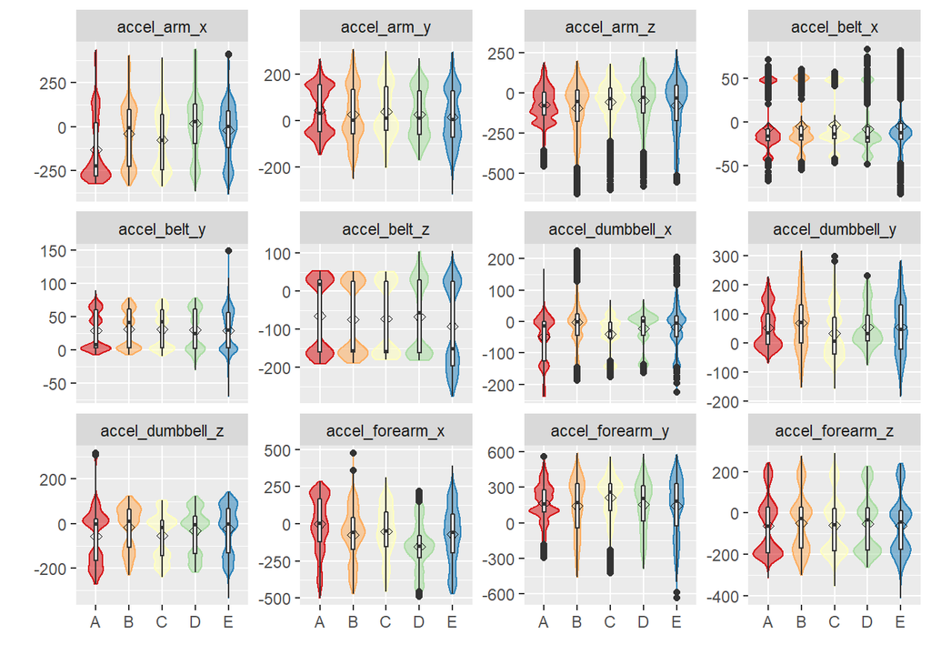

```r
## plot variables as function of classe
trainingSample2 <- trainingSample %>%
        tidyr::pivot_longer(
                cols = starts_with('accel'),
                values_to = 'value'
        )

trainingSample2 %>%
        ggplot(aes(x = classe, y = value)) +
        geom_violin(aes(color = classe, fill = classe, alpha = 0.4)) +
        facet_wrap(~ name, scales = 'free_y') +
        scale_color_brewer(palette = 'Spectral') +
        scale_fill_brewer(palette = 'Spectral') +
        stat_summary(fun = mean, geom = 'point', shape = 23, size = 2) +
        geom_boxplot(width = 0.1) +
        labs(x = "", y = "") +
        theme(legend.position = "none")
```

```r
#####-> Model Fitting with Random Forest package
set.seed(30131)
rf.prelim <- randomForest(
        x = trainingSample[, -1],
        y = trainingSample$classe,
        #mtry = 2,
        #importance = TRUE,
        do.trace = 50      ## to print every fifty trees
)
```

```
## ntree      OOB      1      2      3      4      5
##    50:   0.03%  0.00%  0.09%  0.00%  0.00%  0.05%
##   100:   0.01%  0.00%  0.04%  0.00%  0.00%  0.00%
##   150:   0.01%  0.00%  0.04%  0.00%  0.00%  0.00%
##   200:   0.01%  0.00%  0.04%  0.00%  0.00%  0.00%
##   250:   0.01%  0.00%  0.04%  0.00%  0.00%  0.00%
##   300:   0.01%  0.00%  0.04%  0.00%  0.00%  0.00%
##   350:   0.01%  0.00%  0.04%  0.00%  0.00%  0.00%
##   400:   0.01%  0.00%  0.04%  0.00%  0.00%  0.00%
##   450:   0.01%  0.00%  0.04%  0.00%  0.00%  0.00%
##   500:   0.01%  0.00%  0.04%  0.00%  0.00%  0.00%
```

```r
rf.prelim
```

```
##
## Call:
##  randomForest(x = trainingSample[, -1], y = trainingSample$classe,      do.trace = 50)
##                Type of random forest: classification
##                      Number of trees: 500
## No. of variables tried at each split: 3
##
##         OOB estimate of  error rate: 0.01%
## Confusion matrix:
##      A    B    C    D    E  class.error
## A 3348    0    0    0    0 0.0000000000
## B    0 2278    0    0    1 0.0004387889
## C    0    0 2054    0    0 0.0000000000
## D    0    0    0 1930    0 0.0000000000
## E    0    0    0    0 2165 0.0000000000
```

```r
set.seed(1113)
rf = train(
        x = trainingSample[, -c(1, 2)],
        y = trainingSample$classe,
        method = 'rf',
        trControl = trainControl(method = 'oob'),
        allowParallel = TRUE,
        ntree = 300,
        importance = TRUE,
        tuneLength = 10
)

rf
```

```
## Random Forest
##
## 11776 samples
##    12 predictor
##     5 classes: 'A', 'B', 'C', 'D', 'E'
##
## No pre-processing
## Resampling results across tuning parameters:
##
##   mtry  Accuracy   Kappa
##    2    0.9369056  0.9201533
##    3    0.9367357  0.9199274
##    4    0.9362262  0.9192925
##    5    0.9346128  0.9172553
##    6    0.9311311  0.9128541
##    7    0.9289232  0.9100691
##    8    0.9250170  0.9051182
##    9    0.9235734  0.9032831
##   10    0.9214504  0.9006017
##   12    0.9143173  0.8915417
##
## Accuracy was used to select the optimal model using the largest value.
## The final value used for the model was mtry = 2.
```

```r
## Compare Predictions with Validation Set
preds <- predict(rf, newdata = trainingSample)
confusionMatrix(preds, trainingSample$classe)
```

```
## Confusion Matrix and Statistics
##
##           Reference
## Prediction    A    B    C    D    E
##          A 3348    0    0    0    0
##          B    0 2279    0    0    0
##          C    0    0 2054    0    0
##          D    0    0    0 1930    0
##          E    0    0    0    0 2165
##
## Overall Statistics
##
##                Accuracy : 1
##                  95% CI : (0.9997, 1)
##     No Information Rate : 0.2843
##     P-Value [Acc > NIR] : < 2.2e-16
##
##                   Kappa : 1
##
##  Mcnemar's Test P-Value : NA
##
## Statistics by Class:
##
##                      Class: A Class: B Class: C Class: D Class: E
## Sensitivity            1.0000   1.0000   1.0000   1.0000   1.0000
## Specificity            1.0000   1.0000   1.0000   1.0000   1.0000
## Pos Pred Value         1.0000   1.0000   1.0000   1.0000   1.0000
## Neg Pred Value         1.0000   1.0000   1.0000   1.0000   1.0000
## Prevalence             0.2843   0.1935   0.1744   0.1639   0.1838
## Detection Rate         0.2843   0.1935   0.1744   0.1639   0.1838
## Detection Prevalence   0.2843   0.1935   0.1744   0.1639   0.1838
## Balanced Accuracy      1.0000   1.0000   1.0000   1.0000   1.0000
```

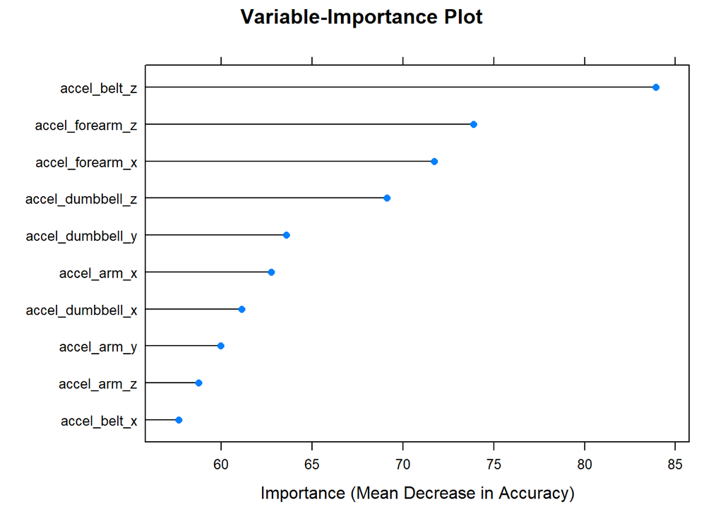

```r
## Show up the most important variable
rf_plot <- varImp(rf, scale = FALSE, type = 1)
plot(
        rf_plot, top = 10, main = 'Variable-Importance Plot',
        xlab = 'Importance (Mean Decrease in Accuracy)'
)
```

```r
## Final Test
test2 <- testing[, keepNames]
test2$user_name <- factor(test2$user_name)

examPreds <- predict(rf, newdata = test2)
results <- matrix(examPreds, nrow = 20)
colnames(results) <- test$problem_id
kable(results)
```

| B |
| --- |
| A |
| C |
| A |
| A |
| E |
| D |
| D |
| A |
| A |
| B |
| C |
| B |
| A |
| E |
| E |
| A |
| B |
| B |
| B |

```r
pml_write_files = function(x){
  n = length(x)
  for(i in 1:n){
    filename = paste0("answers/problem_id_", i, ".txt")
    write.table(x[i],
                file = filename,
                quote = FALSE,
                row.names = FALSE,
                col.names = FALSE)
  }
}-

pml_write_files(examPreds)
```

## REFERENCES

[1] Velloso, E.; Bulling, A.; Gellersen, H.; Ugulino, W.; Fuks, H. Qualitative Activity Recognition of Weight Lifting Exercises. Proceedings of 4th International Conference in Cooperation with SIGCHI (Augmented Human ’13) . Stuttgart, Germany: ACM SIGCHI, 2013.

[2] Ugulino, W.; Ferreira, M.; Velloso, E.; Fuks, H. Virtual Caregiver: Colaboração de Parentes no Acompanhamento de Idosos. Anais do SBSC 2012, IX Simpósio Brasileiro de Sistemas Colaborativos , pp. 43-48. São Paulo, SP: IEEE, 2012. ISBN 978-0-7695-4890-6.

[3] Ugulino, W.; Cardador, D.; Vega, K.; Velloso, E.; Milidiu, R.; Fuks, H. Wearable Computing: Accelerometers’ Data Classification of Body Postures and Movements. Proceedings of 21st Brazilian Symposium on Artificial Intelligence. Advances in Artificial Intelligence - SBIA 2012. In: Lecture Notes in Computer Science. , pp. 52-61. Curitiba, PR: Springer Berlin / Heidelberg, 2012. ISBN 978-3-642-34458-9. DOI: 10.1007/978-3-642-34459-6_6.

[4] R Core Team (2020). R: A language and environment for statistical computing. R Foundation for Statistical Computing, Vienna, Austria. URL https://www.R-project.org/.